# Ventilation Prediction Using Machine Learning: A Comparative Analysis of Models

Author

Nicole Sorensen

Published

May 16, 2025

## Introduction

Mechanical ventilation (MV) is a critical life-support intervention used in over 20% of intensive care unit (ICU) admissions. However, accurately and timely predicting the need for ventilation remains a significant challenge in hospitals. Failure to identify patients who need breathing support soon enough can increase mortality risk, while premature initiation of ventilation may cause complications such as ventilator-associated pneumonia and vocal cord injury. Identifying these patients early provides the time for clinicians to adjust care plans and for hospitals to allocate resources efficiently, potentially improving patient survival and health outcomes.

Hospitals have increasingly adopted machine learning to support real-time early diagnosis, medical image interpretation, and treatment decisions. These predictive models have the potential to help alleviate the burden on clinicians of managing numerous clinical variables and to help uncover more complex trends in patient data that are not readily apparent. The development of these actionable models is driven by the emergence of large electronic health records (EHR) datasets, which contain granular details of patients’ hospital stays. Consequently, recent years have seen a significant rise in models trained on these datasets for critical care applications, such as risk stratification and outcome prediction.

Since the start of the COVID-19 pandemic in 2020, many studies have explored machine learning for predicting outcomes for COVID-19 patients. Douville et al. (2020) developed a random forest model to predict mechanical ventilation or death within 4, 8, 24, and 48 hours, showing promising utility in pandemic response, though lacking a gap between feature collection and the prediction window for real-time applicability. Similarly, Aljouie et al. (2021) combined chest radiographs, laboratory, and clinical data to predict MV requirements, showing that multimodal data improved model performance.

Advancements in training approaches and model architecture have further improved mechanical ventilation prediction capabilities. Bendavid et al. (2022) applied transfer learning to adapt an XGBoost model trained on a broader critically ill patient cohort for COVID-19-specific predictions, addressing challenges with small datasets. Mohanty et al. (2024) introduced cross-attention mechanisms to deep learning models, improving performance by better capturing interactions between temporal and static features. Ashrafi et al. (2024) enhanced interpretability of deep learning for mortality prediction in ventilated patients by applying SHAP analysis on MIMIC-III data (2001-2012). However, reliance on outdated datasets and and limited inclusion of data sources, such as clinical notes or imaging, provide opportunities for further improvement.

This study aims to address these gaps by developing a machine learning model for mechanical ventilation prediction, integrating structured (e.g. vitals, labs) and unstructured (e.g. clinical notes) data. By incorporating a temporal prediction window with a clinically relevant gap and leveraging multimodal data, this work seeks to advance MV prediction while maximizing practical applicability in real-time clinical settings.

## Data

The data was sourced from the MIMIC-IV dataset which is a publicly available database containing patients admitted to the emergency department or intensive care unit of the Beth Israel Deaconess Medical Center. This data was de-identified and is available upon completion of human subjects research training and signing a data use agreement. Patients that were younger than 18 on their first visit or who were on a list of people requiring enhanced protection were excluded. This data was grouped into three separate modules: hosp, icu, and note. Hosp includes patient records from admission, discharge, and transfer, as well as lab values and medications. The icu module includes data documented while patients were in the ICU such as vital measurements, procedures, and patient outputs. The note module includes free-text notes written by clinicians from radiology reports or discharge summaries. Discharge summaries were excluded from this analysis because they were produced upon a patient exiting the hospital and would not be available for use in real-time prediction.

## Preprocessing

Due to constraints on computational resources, this study sampled 20,000 patients from the total 65,000 patients admitted to the ICU in the MIMIC-IV database and used SQL to extract the matching records from all data tables for those patients. In order to make the model predictions timely and accurate, a 6-hour sliding window of patient data was used to predict ventilation needs within a 4-hour window following a 2 hour gap, inspired by Bendavid et al. (2022). The 6-hour sliding window was used so that only the most recent patient data would be considered to assess the patient’s condition so recent signs of deterioration are not washed out by earlier patient data. The 2-hour gap is necessary to reduce the risk of data leakage because making a prediction without a gap might lead to the model learning immediate pre-event indicators, which may not provide enough time for proper preparation and precautions to be taken. This allows for focus on earlier indicators of deterioration rather than late-stage symptoms. The length of the gap was chosen to be 2 hours because this more closely mirrors how clinicians predict intervention needs in practice. This process is illustrated as follows:

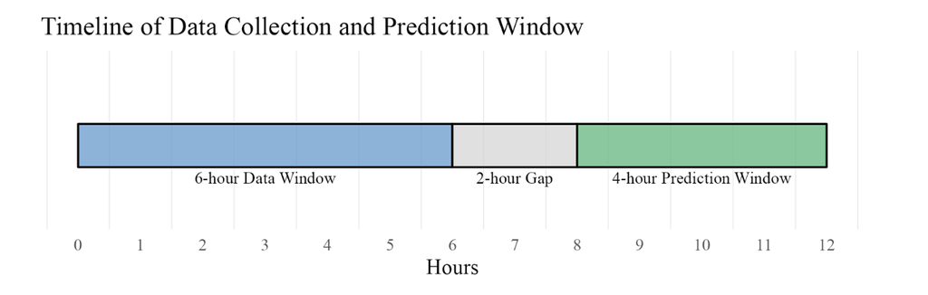

In order to align with this prediction format, the data was restructured so that the instances in the datasets represented non-overlapping 6-hour periods of data from a hospital admission. Periods where the patient was not in the ICU were also removed due to the sparsity of data, limiting generalizable to just ICU patients. Instances after the first ventilation event were excluded to avoid data leakage.

For baseline models like logistic regression, which can not implicitly models dependencies between variables (e.g. dependencies between hours of one vital), aggregation strategies (min, max, mean, slope) were deployed to compress multiple measurements in one data window into a single value, inspired by Ye et al. (2022). For missing values, since some measurements may only be recorded if a clinician thinks a patient is deteriorating, the fact that a value is missing might be informative. To resolve this, separate binary indicator variables were added for each feature with missing values.

For the deep learning models, the data was binned into hourly values instead of aggregating across the whole six-hour period, because this retains the complete temporal structure of the data, allowing models to capture more complex nonlinear trends. Just as before, a mask variables were created to indicate missingness. Furthermore, since this data is in time-series form and many features are sparse, a time since the last observation feature was added for every feature with missing values as done in Bendavid et al. (2022). For hours where the last observed value was unknown, these were marked with a placeholder value of -1 and handled in a masking layer of the deep learning models, ensuring that the missing values don not affect gradients. Numeric features were normalized using MinMaxScaler which scales each feature to be between 0 and 1.

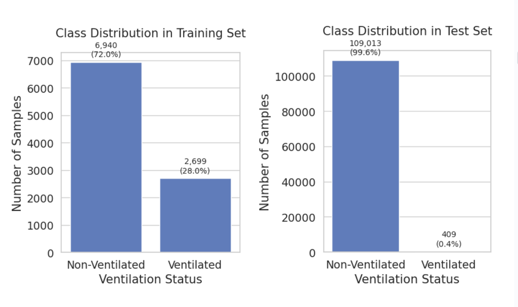

The class distribution in the training set vs the test set is illustrated above. The test set after preprocessing included 109,013 non-ventilation instances and 409 ventilation instances. In order to have enough ventilation instances to evaluate model choices, the test data was split in half to obtain a validation set and a final test set using stratified random sampling on the ventilation variable. The final test set was stored away until the end to be used as a measure of the final performance of the models.

## Feature selection

Since the MIMIC-IV database contains hundreds of variables, feature selection was used in order to reduce the dimensionality of the data to produce a model that is interpretable and robust. The feature selection method used was the Boruta algorithm, which is a wrapper method built on top of random forests. It evaluates the importance of real features by comparing their variable importance to ‘shadow features’ which are randomized versions (permutations) of the original features. Features consistently outperforming shadow features are retained, discarding the rest.

Features with less than 10% nonmissing values were excluded and static variables, like prior diagnoses, were removed if they had less than 1% positive values, resulting in the removal of diabetes, cancer, renal dysfunction, and sepsis. Of the 121 features initially considered, 73 were removed after Boruta feature selection (using 50 estimators and 75 percentile threshold), leaving 48 non-text features. A correlation analysis of the remaining features revealed that several pairs were perfectly correlated (correlation of 1.0); in these cases, one feature from each pair was removed.

**Table 1: Selected dynamic features from Boruta feature selection**

| Feature Category | Mean | Min | Max | Slope | Missing_Indicator |
| --- | --- | --- | --- | --- | --- |
| pH | ✔ | ✔ | ✔ | ✔ | ✔ |
| pCO2 | ✔ | ✔ | ✔ | ✔ | ✔ |
| pO2 | ✔ | ✔ | ✔ | ✔ | ✔ |
| O2 Saturation | ✔ | ✔ | ✔ | ✔ | ✔ |
| Respiratory Rate | ✔ | ✔ | ✔ | ✔ | ✔ |
| Heart Rate | ✔ | ✔ | ✔ | ✔ |  |
| Arterial Base Excess | ✔ | ✔ | ✔ |  | ✔ |
| Temperature | ✔ | ✔ | ✔ | ✔ |  |
| Arterial Blood Pressure | ✔ | ✔ | ✔ | ✔ | ✔ |
| Hemoglobin | ✔ | ✔ | ✔ |  |  |
| Lactate | ✔ | ✔ | ✔ |  | ✔ |
| Bicarbonate | ✔ | ✔ | ✔ |  |  |
| Creatinine | ✔ | ✔ | ✔ |  |  |
| Glucose | ✔ | ✔ | ✔ |  |  |

## Baseline modeling

The primary performance metric used was Precision-Recall AUC (PR AUC). Precision measures how accurate the model’s positive predictions were and recall measures how accurate the model was on true positive patients. PR AUC is particularly informative on imbalanced datasets since it emphasizes the performance of the minority class. Additional metrics, including balanced accuracy, which averages the recall of both classes, and F1-score, which provides a harmonic mean of precision and recall for the positive class, were also reported to supplement the PR AUC.

The logistic regression model achieved a PR AUC of 0.006, a balanced accuracy of 0.5476, and an F1-score of 0.0225 on the validation set. These results indicate a bias towards the majority class, with limited ability to correctly identify instances requiring ventilation within the prediction window.

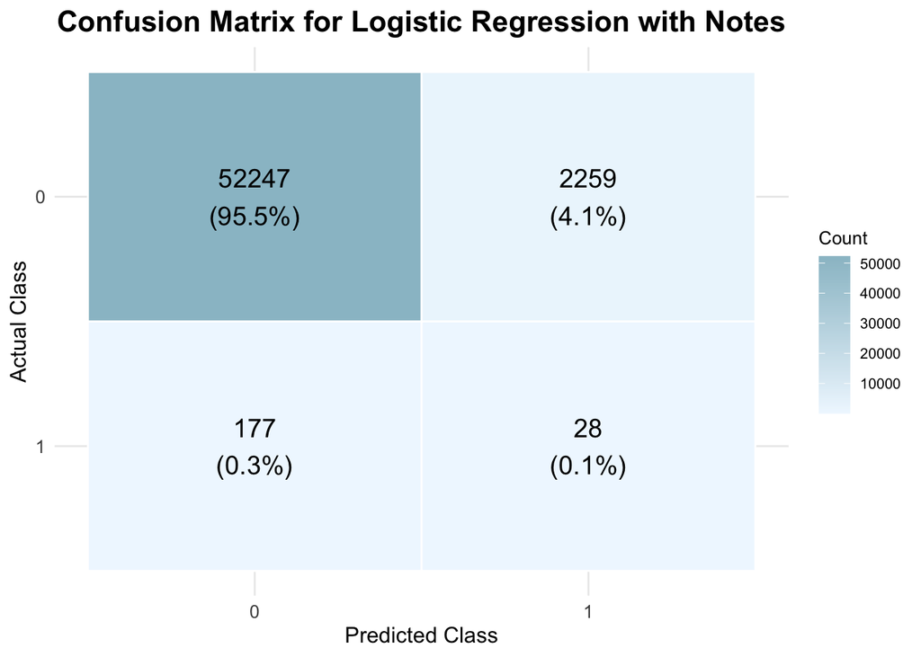

The above confusion matrix shows that the model was not able to discriminate well between people who did not need ventilation and those who did, with 2259 false positives and only 28 out of 205 true ventilated patients were accurately predicted.

To evaluate the utility of the free-text clinical notes, a logistic regression model without the notes was also trained using the same method as above. This model obtained a balanced accuracy of 0.5254, slightly lower than the model with the free text notes, and the same PR-AUC, suggesting that the addition of the clinical notes provide marginal improvements.

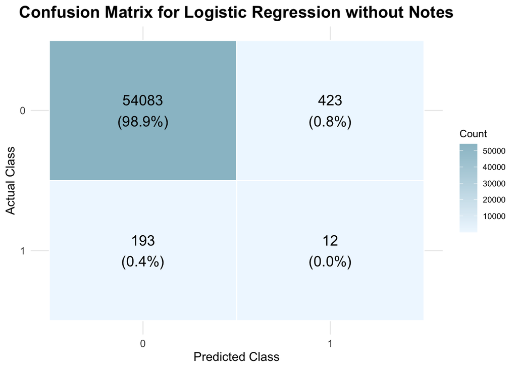

The confusion matrix above shows fewer false positives, but lower recall, highlighting the notes’ utility.

## Error analysis

To understand misclassifications, we analyzed false positives in the logistic regression model. Features with high horizontal absolute differences (HADs) and high feature weights were examined. High HAD values suggest that the feature makes the false positives look different from correctly predicted instances, while high feature weights indicate that the feature had a large influence on making that prediction.

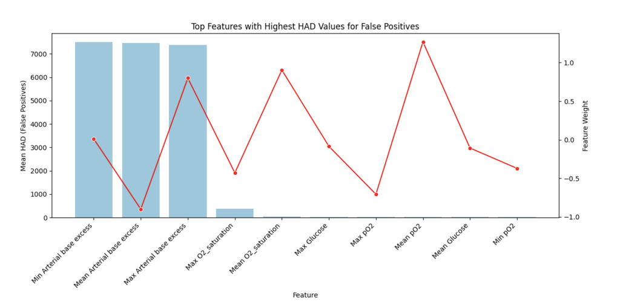

The mean horizontal absolute distances (HADs) are depicted by the light blue bars, while the feature weights are depicted by the red dots. Upon inspection, max arterial base excess had both a high HAD and high feature weight, indicating that it may be confusing the model. To determine how max arterial base excess might be contributing to false positives, a correlation analysis was performed to identify relationships between max arterial base excess and other features to see how they overlap in their contribution to the model’s predictions.

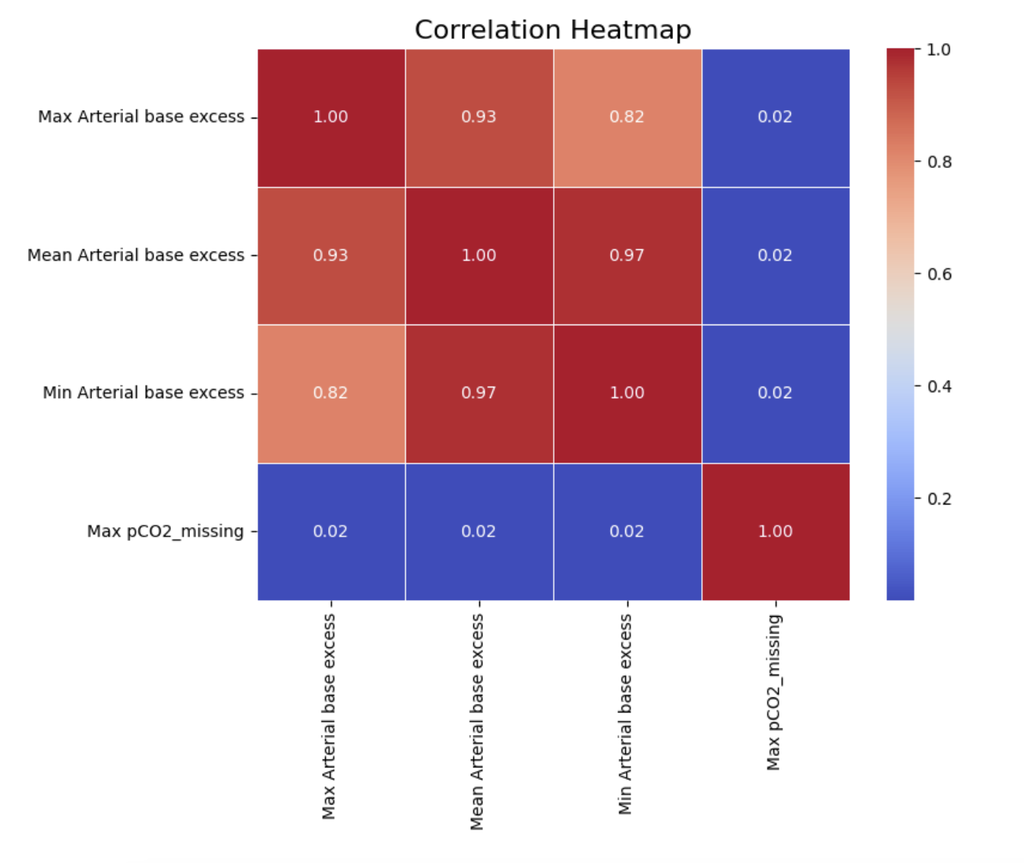

Unsurprisingly, Max Arterial base excess had a high correlation with Mean Arterial base excess (0.93) and Min Arterial base excess (0.82) but these features had radically different feature weights (mean arterial base excess: -0.899, min arterial base excess: 0.011), potentially creating conflicting signals in the model. The opposite feature weights of highly correlated features suggest that logistic regression is struggling to disentangle their individual contributions due to multicollinearity. These feature weights suggest that Max Arterial base excess’s high positive weight is pushing the model towards incorrectly predicting ventilation when max Arterial base excess is high, while mean and min Arterial base excess’s weights don’t sufficiently counteract this effect. Since just removing max Arterial base excess would remove potentially useful information, instead, the correlated features were combined into a single metric, where range Arterial base excess was calculated from max Arterial base excess and min Arterial base excess.

After augmenting the dataset with the new range Arterial base excess feature, 5-fold cross-validation yielded an average PR AUC of 0.006, the same as the baseline PR AUC. This suggests that the influence of Max Arterial base excess is not solely attributable to multicollinearity. It is possible that Max Arterial base excess interacts with other variables in ways that are not effectively captured by the linear relationships assumed in logistic regression, indicating the need for models capable of handling complex interactions.

In order to avoid manually trying to add interaction terms to the logistic regression model, as a secondary baseline model, a random forest classifier was trained. Random forests are models that use the majority vote of many independent decision trees in order to make classifications. This allows for automatic handling of interactions due to the structure of tree-based models and random forests are robust models that do not require as much hyperparameter tuning like XGBoost. The PR AUC from training a random forest model after hyperparameter tuning (best parameters: 200 estimators, 5 min samples split, 2 min samples leaf, 30 max depth) and 5-fold cross validation was 0.0418, which is 7 times higher than the PR AUC for the logistic regression model. This model had a balanced accuracy of 0.7854 and F1-score of 0.0394, which were both also higher than the baseline metrics.

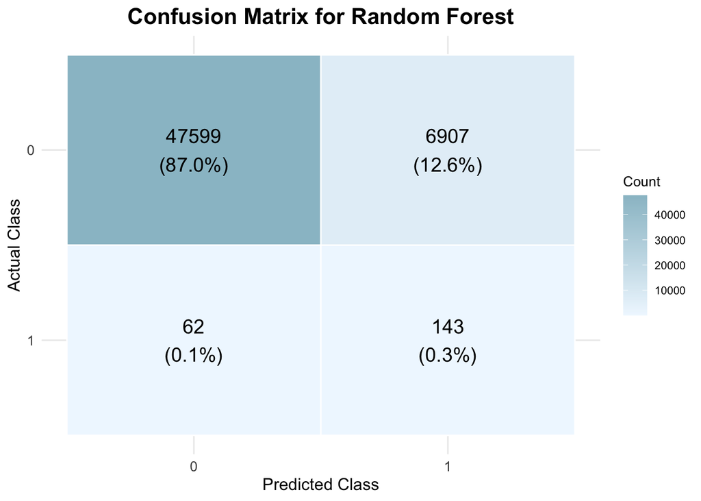

As indicated by the confusion matrix above, the recall, which is the accuracy rate for true positives, is much higher for the random forest (0.70) compared to the baseline logistic regression model (0.14). However, there are still a significant number of false positives, meaning that many people are predicted to need ventilation when they actually don’t. This could result in ventilator related complications, demanding a more precise model.

An XGBoost model, which uses a sequence of weak learners, each learning from the mistakes of the previous one, was also trained. The XGBoost model, using a positive class weight of 5 and log loss as the eval metric, got a PR AUC of 0.027, significantly worse than the random forest model. The poor performance was likely due to insufficient hyperparameter tuning.

## Deep Learning

The next type of architecture considered was a multi-input deep learning model that combines an LSTM model for the time-series data and ClinicalBERT, a text embedding model, for the clinical notes, then combining the outputs into a dense layer, taking inspiration from the approach by Deznabi et al. (2021).

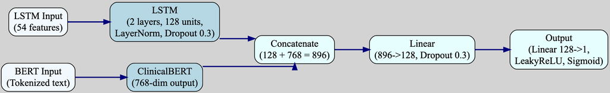

The time-series data required further preprocessing for deep learning. Missing values were handled by forward fill using the last observed value. The remaining missing values for the time series features were imputed using the mean value for the age bracket of the patient. Age brackets were determined by rounding the patients’ anchor age to the nearest tens place.

Time-since-last and missing indicator features were also added, where time-since-last is the time since the last observed value. If the last observed value was unknown, a placeholder value of -1 was used, which was dealt with using a masking layer in the LSTM, so the model would ignore those values. Static features were dealt with using mean imputation. Standardization was applied to all features using min-max scaling. All imputed values and standardization were based on statistics from the training data to prevent data leakage.

The LSTM branch of the model takes in the time series data for each six hour period, where each input vector has six entries which are the normalized average values of that feature at each hour. The LSTM was fit with a hidden size of 128, 2 hidden layers, and a learning rate of 0.0001. Layer normalization, dropout of 0.3, and leaky ReLU activation functions were applied to prevent gradients from vanishing.

The ClinicalBERT branch takes in the tokenized clinical notes and outputs a CLS token layer. The final fusion layer then concatenates the LSTM output and ClinicalBERT output and passes it through one fully connected layer. A sigmoid activation function is used at the end to output the probability of a patient needing ventilation in the prediction window.

Since there is a significant class imbalance, Binary Cross-Entropy with Logits Loss, a loss function that combines a sigmoid layer and binary cross-entropy loss in one single function, was used in order to penalize the model more for misclassifying the minority class (positive weight of 5). Also since ClinicalBERT requires a smaller learning rate for fine-tuning, a learning rate of 1e-5 was used for parameters from the ClinicalBERT model, while a learning rate of 1e-4 was used for all other parameters.

Training was done with a batch size of 32. In order to prevent overfitting, validation monitoring for early stopping was applied, using F1-score and a patience of 3. Batches with all empty notes were skipped in training to prevent constant ClinicalBERT outputs. Gradients were clipped using a max norm of 5.0 to prevent exploding gradients. The prediction threshold was tuned using the validation set, resulting in 0.94 as the optimal threshold. The model obtained a PR AUC of 0.0400 and F1-score of 0.1197 on the validation set.

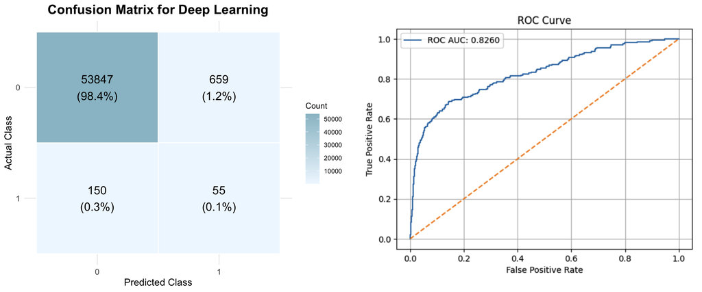

The deep learning model had less false positives than the random forest, however, it failed to identify as many patients who truly needed to be on ventilation, resulting in a lower PR AUC. This may be a result of overfitting.

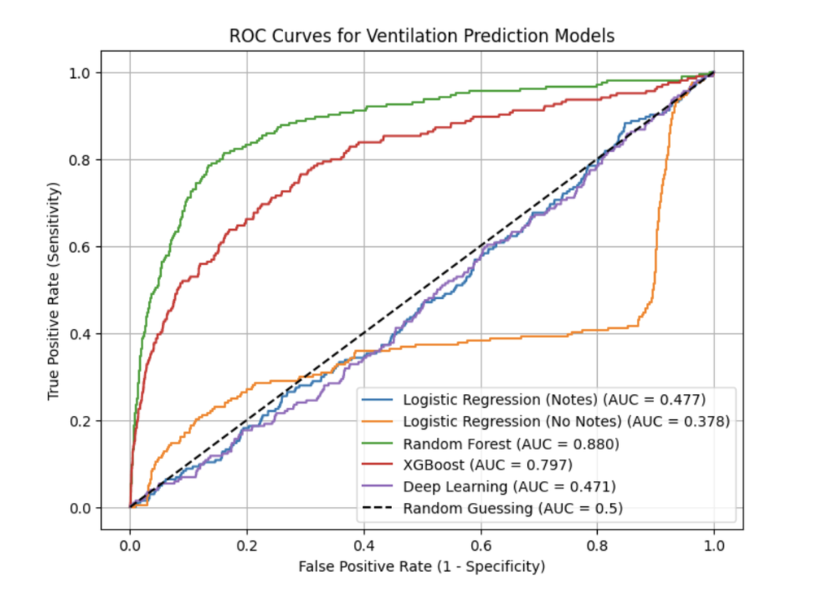

## Discussion

Future work could employ advanced class imbalance techniques, such as generative adversarial networks or reinforcement learning, as explored by Li et al. (2025), to better handle the low prevalence of ventilation events. Also, fine-tuning ClinicalBERT on radiology reports or incorporating more advanced time-series models like transformers may better capture nuanced temporal and textual patterns in the data. Finally, a prospective validation study in a real-world ICU setting would be necesary to confirm the model’s clinical utility and refine its integration into hospital workflows.

## References

Ahmed, A. M., Deo, R. C., Feng, Q., Ghahramani, A., Raj, N., Yin, Z., & Yang, L. (n.d.). Deep learning hybrid model with Boruta-Random forest optimiser algorithm for streamflow forecasting with climate mode indices, rainfall, and periodicity. *Journal of Hydrology*, 599, 126350. https://doi.org/10.1016/j.jhydrol.2021.126350

Ali, M. (2022, June 10). Boruta feature selection explained in Python - geek Culture - medium. *Medium.* https://medium.com/geekculture/boruta-feature-selection-explained-in-python-7ae8bf4aa1e7

Ashrafi, N., Liu, Y., Xu, X., Wang, Y., Zhao, & Pishgar, M. (2022). Deep learning model utilization for mortality prediction in mechanically ventilated ICU patients. *ScienceDirect*, 49. https://doi.org/10.1016/j.imu.2024.101562

Aslam, N. (2022). Explainable artificial intelligence approach for the early prediction of ventilator support and mortality in COVID-19 patients. *Computation*, 10(3), 36. https://doi.org/10.3390/computation10030036

Beckman, K. D. (2014, March 15). *How to document and code for hypertensive diseases in ICD-10.* AAFP. https://www.aafp.org/pubs/fpm/issues/2014/0300/p5.html

Bendavid, I., Statlender, L., Shvartser, L., Teppler, S., Azullay, R., Sapir, R., & Singer, P. (2022). A novel machine learning model to predict respiratory failure and invasive mechanical ventilation in critically ill patients suffering from COVID-19. *Scientific Reports*, 12(1). https://doi.org/10.1038/s41598-022-14758-x

Chen, P., Selvaraj, A., & Jahagirdar, O. (n.d.). Predicting Associated Comorbidities of Obesity from MIMIC IV Clinical Notes. In Stanford CS224N, Stanford CS224N Custom Project. https://web.stanford.edu/class/archive/cs/cs224n/cs224n.1234/final-reports/final-report-169508001.pdf

*Diseases of the respiratory system - ICD-10 Codes- Codify by AAPC.* (n.d.). https://www.aapc.com/codes/icd-10-codes-range/J00-J99/

Douville, N. J., Douville, C. B., Mentz, G., Mathis, M. R., Pancaro, C., Tremper, K. K., & Engoren, M. (2020). Clinically applicable approach for predicting mechanical ventilation in patients with COVID-19. *British Journal of Anaesthesia*, 126(3), 578–589. https://doi.org/10.1016/j.bja.2020.11.034

Goldberger, A., Amaral, L., Glass, L., Hausdorff, J., Ivanov, P. C., Mark, R., … & Stanley, H. E. (2000). PhysioBank, PhysioToolkit, and PhysioNet: Components of a new research resource for complex physiologic signals. Circulation [Online]. 101 (23), pp. e215–e220.

Hou, N., Li, M., He, L., Xie, B., Wang, L., Zhang, R., Yu, Y., Sun, X., Pan, Z., & Wang, K. (2020). Predicting 30-days mortality for MIMIC-III patients with sepsis-3: a machine learning approach using XGboost. *Journal of Translational Medicine*, 18(1). https://doi.org/10.1186/s12967-020-02620-5

Li, Z., Jiang, H., & Wang, X. (n.d.). A Novel Reinforcement Learning Agent for Rotating Machinery Fault Diagnosis with Data Augmentation. *Reliability Engineering & System Safety*, 253, 110570. https://doi.org/10.1016/j.ress.2024.110570

Johnson, A., Bulgarelli, L., Pollard, T., Gow, B., Moody, B., Horng, S., Celi, L. A., & Mark, R. (2024). MIMIC-IV (version 3.1). *PhysioNet*. https://doi.org/10.13026/kpb9-mt58.

Johnson, A.E.W., Bulgarelli, L., Shen, L. et al. MIMIC-IV, a freely accessible electronic health record dataset. Sci Data 10, 1 (2023). https://doi.org/10.1038/s41597-022-01899-x

Johnson, A., Pollard, T., Horng, S., Celi, L. A., & Mark, R. (2023). MIMIC-IV-Note: Deidentified free-text clinical notes (version 2.2). *PhysioNet*. https://doi.org/10.13026/1n74-ne17.

Liu, M., Fan, Z., Gao, Y., Mubonanyikuzo, V., Wu, R., Li, W., Xu, N., Liu, K., & Zhou, L. (2024). A two-tier feature selection method for predicting mortality risk in ICU patients with acute kidney injury. *Scientific Reports*, 14(1). https://doi.org/10.1038/s41598-024-63793-3

Liu, X., Liu, H., Yang, G., Jiang, Z., Cui, S., Zhang, Z., Wang, H., Tao, L., Sun, Y., Song, Z., Hong, T., Yang, J., Gao, T., Zhang, J., Li, X., Zhang, J., Sang, Y., Yang, Z., Xue, K., . . . Wang, G. (2025). A generalist medical language model for disease diagnosis assistance. *Nature Medicine*. https://doi.org/10.1038/s41591-024-03416-6

Mohanty, A., Shashikumar, S. P., Lam, J. Y., & Nemati, S. (2024, July 21). Improving Prediction of Need for Mechanical Ventilation using Cross-Attention. *arXiv.org*. https://arxiv.org/abs/2407.15885

*Neoplasms - ICD-10 codes- Codify by AAPC.* (n.d.). https://www.aapc.com/codes/icd-10-codes-range/C00-D49/?srsltid=AfmBOopBRX1KnGLnJuFprdbtDYSYpVvh7qSbpXb6Y3KmBwzUiGHUXnlY

Rahman, M. M., & Davis, D. N. (2013). Addressing the class imbalance problem in medical datasets. *International Journal of Machine Learning and Computing*, 224–228. https://doi.org/10.7763/ijmlc.2013.v3.307

Scikit-Learn-Contrib. (n.d.). boruta_py/README.md at master · scikit-learn-contrib/boruta_py. GitHub. https://github.com/scikit-learn-contrib/boruta_py/blob/master/README.md

Shashikumar, S. P., Wardi, G., Paul, P., Carlile, M., Brenner, L. N., Hibbert, K. A., North, C. M., Mukerji, S. S., Robbins, G. K., Shao, Y., Westover, M. B., Nemati, S., & Malhotra, A. (n.d.). Development and Prospective Validation of a Deep Learning Algorithm for Predicting Need for Mechanical Ventilation. *CHEST Journal*, 159(6), 2264–2273. https://doi.org/10.1016/j.chest.2020.12.009

Stivi, T., Padawer, D., Dirini, N., Nachshon, A., Batzofin, B. M., & Ledot, S. (2024). Using Artificial Intelligence to Predict Mechanical Ventilation Weaning Success in Patients with Respiratory Failure, Including Those with Acute Respiratory Distress Syndrome. *Journal of Clinical Medicine*, 13(5), 1505. https://doi.org/10.3390/jcm13051505

Wang, Z., Zhang, L., Huang, T., Yang, R., Cheng, H., Wang, H., Yin, H., & Lyu, J. (n.d.). Developing an explainable machine learning model to predict the mechanical ventilation duration of patients with ARDS in intensive care units. *Heart & Lung*, 58, 74–81. https://doi.org/10.1016/j.hrtlng.2022.11.005

Ye, W., Li, R., Liang, H., Huang, Y., Xu, Y., Li, Y., Ou, L., Mao, P., Liu, X., & Li, Y. (2022). Development and validation of a clinical risk model to predict the hospital mortality in ventilated patients with acute respiratory distress syndrome: a population-based study. *BMC Pulmonary Medicine*, 22(1). https://doi.org/10.1186/s12890-022-02057-0

Yong, L., & Zhenzhou, L. (2024). Deep learning-based prediction of in-hospital mortality for sepsis. *Scientific Reports*, 14(1). https://doi.org/10.1038/s41598-023-49890-9

Zhu, Y., Zhang, J., Wang, G., Yao, R., Ren, C., Chen, G., Jin, X., Guo, J., Liu, S., Zheng, H., Chen, Y., Guo, Q., Li, L., Du, B., Xi, X., Li, W., Huang, H., Li, Y., & Yu, Q. (2021). Machine learning prediction models for mechanically ventilated patients: Analyses of the MIMIC-III database. *Frontiers in Medicine*, 8. https://doi.org/10.3389/fmed.2021.662340